# AllLife Credit Card Customer Segmentation

## Context

AllLife Bank wants to focus on its credit card customer base in the next financial year. The Marketing team proposes to run personalised campaigns to target new customers as well as upsell to existing customers and the Operations team wants to upgrade the service delivery model to ensure that customers queries are resolved faster.

## Objective

- To identify different segments in the existing customer based on their spending patterns as well as past interaction with the bank.
- Group the data points using Kmeans clustering and Hierarchical clustering and identify the best one based on the silhouette score
- Generate a set of insights and recommendations that will help the bank

## Key questions to be answered

- How many different segments of customers are there?
- How are these segments different from each other?
- What are your recommendations to the bank on how to better market to and service these customers?

## Data Description

Data is of various customers of a bank with their credit limit, the total number of credit cards the customer has, and different channels through which customer has contacted the bank for any queries, different channels include visiting the bank, online and through a call centre.

1. Sl_No: Primary key of the records
2. Customer Key: Customer identification number
3. Average Credit Limit: Average credit limit of each customer for all credit cards
4. Total credit cards: Total number of credit cards possessed by the customer
5. Total visits bank: Total number of Visits that customer made (yearly) personally to the bank
6. Total visits online: Total number of visits or online logins made by the customer (yearly)
7. Total calls made: Total number of calls made by the customer to the bank or its customer service department (yearly)

# Load and explore the dataset

## Import the necessary packages

Let's start by importing libraries we need.

```python
# To help with reading and manipulating data
import pandas as pd
import numpy as np

# To help with data visualization
#%matplotlib inline
import matplotlib.pyplot as plt
import seaborn as sns

# To impute missing values
from sklearn.impute import KNNImputer

# to scale the data using z-score
from sklearn.preprocessing import StandardScaler

# to compute distances
from scipy.spatial.distance import cdist, pdist

# to perform k-means clustering and AgglomerativeClustering
from sklearn.cluster import KMeans, AgglomerativeClustering

# to compute silhouette scores
from sklearn.metrics import (
    silhouette_score,
    adjusted_rand_score,
    fowlkes_mallows_score,
    calinski_harabasz_score,
)

# to visualize the elbow curve and silhouette scores
from yellowbrick.cluster import KElbowVisualizer, SilhouetteVisualizer
import matplotlib.cm as cm

# to perform hierarchical clustering, compute cophenetic correlation, and create dendrograms
from scipy.cluster.hierarchy import dendrogram, linkage, cophenet

# to perform PCA
from sklearn.decomposition import PCA

# --------------------------------------------------------------------------------

# This will help in making the Python code more structured automatically (good coding practice)
%reload_ext nb_black

# Library to suppress warnings or deprecation notes
import warnings

warnings.filterwarnings("ignore")

# Removes the limit for the number of displayed columns
pd.set_option("display.max_columns", None)
# Sets the limit for the number of displayed rows
pd.set_option("display.max_rows", 200)

pd.set_option("display.max_colwidth", 0)
```

## Read the dataset

```python
# loading the dataset
data = pd.read_excel("datasets/Credit Card Customer Data.xlsx")
df = data.copy()
```

## Understand the shape of the dataset.

```python
# checking shape of the data
print(f"There are {df.shape[0]} rows and {df.shape[1]} columns.")
```

```
There are 660 rows and 7 columns.
```

## View the first and last 5 rows and sample of the dataset

```python
df.head()
```

|  | Sl_No | Customer Key | Avg_Credit_Limit | Total_Credit_Cards | Total_visits_bank | Total_visits_online | Total_calls_made |
| --- | --- | --- | --- | --- | --- | --- | --- |
| 0 | 1 | 87073 | 100000 | 2 | 1 | 1 | 0 |
| 1 | 2 | 38414 | 50000 | 3 | 0 | 10 | 9 |
| 2 | 3 | 17341 | 50000 | 7 | 1 | 3 | 4 |
| 3 | 4 | 40496 | 30000 | 5 | 1 | 1 | 4 |
| 4 | 5 | 47437 | 100000 | 6 | 0 | 12 | 3 |

```python
df.tail()
```

|  | Sl_No | Customer Key | Avg_Credit_Limit | Total_Credit_Cards | Total_visits_bank | Total_visits_online | Total_calls_made |
| --- | --- | --- | --- | --- | --- | --- | --- |
| 655 | 656 | 51108 | 99000 | 10 | 1 | 10 | 0 |
| 656 | 657 | 60732 | 84000 | 10 | 1 | 13 | 2 |
| 657 | 658 | 53834 | 145000 | 8 | 1 | 9 | 1 |
| 658 | 659 | 80655 | 172000 | 10 | 1 | 15 | 0 |
| 659 | 660 | 80150 | 167000 | 9 | 0 | 12 | 2 |

```python
# viewing a random sample of the dataset
data.sample(n=10, random_state=1)
```

|  | Sl_No | Customer Key | Avg_Credit_Limit | Total_Credit_Cards | Total_visits_bank | Total_visits_online | Total_calls_made |
| --- | --- | --- | --- | --- | --- | --- | --- |
| 547 | 548 | 38125 | 26000 | 4 | 5 | 2 | 4 |
| 353 | 354 | 94437 | 9000 | 5 | 4 | 1 | 3 |
| 499 | 500 | 65825 | 68000 | 6 | 4 | 2 | 2 |
| 173 | 174 | 38410 | 9000 | 2 | 1 | 5 | 8 |
| 241 | 242 | 81878 | 10000 | 4 | 5 | 1 | 3 |
| 341 | 342 | 70779 | 18000 | 4 | 3 | 2 | 0 |
| 647 | 648 | 79953 | 183000 | 9 | 0 | 9 | 2 |
| 218 | 219 | 28208 | 19000 | 3 | 1 | 5 | 7 |
| 120 | 121 | 16577 | 10000 | 4 | 2 | 4 | 6 |
| 134 | 135 | 31256 | 13000 | 4 | 1 | 5 | 7 |

**Observations:**

- *Sl_No* column is the primary key of the record
- *Customer Key* column is the ID for the customer
- *Average Credit Limit*, *Total credit cards*, *Total visits bank*, *Total visits online*, *Total calls made* are all numerical columns

## Check the columns in the data

```python
df.index
```

```
RangeIndex(start=0, stop=660, step=1)
```

```python
print(df.columns)
```

```
Index(['Sl_No', 'Customer Key', 'Avg_Credit_Limit', 'Total_Credit_Cards',
       'Total_visits_bank', 'Total_visits_online', 'Total_calls_made'],
      dtype='object')
```

## Check the data types of the columns

```python
df.info()
```

```
<class 'pandas.core.frame.DataFrame'>
RangeIndex: 660 entries, 0 to 659
Data columns (total 7 columns):
 #   Column               Non-Null Count  Dtype
---  ------               --------------  -----
 0   Sl_No                660 non-null    int64
 1   Customer Key         660 non-null    int64
 2   Avg_Credit_Limit     660 non-null    int64
 3   Total_Credit_Cards   660 non-null    int64
 4   Total_visits_bank    660 non-null    int64
 5   Total_visits_online  660 non-null    int64
 6   Total_calls_made     660 non-null    int64
dtypes: int64(7)
memory usage: 36.2 KB
```

**Observations:**

- Average Credit Limit, Total credit cards, Total visits bank, Total visits online, Total calls made are of *int64* datatype
- There are no missing values in any of the columns

## Check for missing values

```python
# looking at which columns have the most missing values
round(df.isnull().sum() / df.isnull().count() * 100, 2)
```

```
Sl_No                  0.0
Customer Key           0.0
Avg_Credit_Limit       0.0
Total_Credit_Cards     0.0
Total_visits_bank      0.0
Total_visits_online    0.0
Total_calls_made       0.0
dtype: float64
```

- We can confirm that there are no missing values in any of the columns

## Check for duplicate values

```python
df.duplicated().sum()
```

```
0
```

- There are no duplicate values in the dataset

## Summary of the dataset

```python
### let's view the statistical summary of the numerical columns in the data
df.describe().T
```

|  | count | mean | std | min | 25% | 50% | 75% | max |
| --- | --- | --- | --- | --- | --- | --- | --- | --- |
| Sl_No | 660.0 | 330.500000 | 190.669872 | 1.0 | 165.75 | 330.5 | 495.25 | 660.0 |
| Customer Key | 660.0 | 55141.443939 | 25627.772200 | 11265.0 | 33825.25 | 53874.5 | 77202.50 | 99843.0 |
| Avg_Credit_Limit | 660.0 | 34574.242424 | 37625.487804 | 3000.0 | 10000.00 | 18000.0 | 48000.00 | 200000.0 |
| Total_Credit_Cards | 660.0 | 4.706061 | 2.167835 | 1.0 | 3.00 | 5.0 | 6.00 | 10.0 |
| Total_visits_bank | 660.0 | 2.403030 | 1.631813 | 0.0 | 1.00 | 2.0 | 4.00 | 5.0 |
| Total_visits_online | 660.0 | 2.606061 | 2.935724 | 0.0 | 1.00 | 2.0 | 4.00 | 15.0 |
| Total_calls_made | 660.0 | 3.583333 | 2.865317 | 0.0 | 1.00 | 3.0 | 5.00 | 10.0 |

**Observations:**

- The average credit limit has a wide range from 3000 to 200000. 75 percentile is only 48000. We need to check if this credit limit is outlier or not.
- Total credit cards owned by a customer range from 1 to 10.
- Total customer visits to a bank is between 0 and 5.
- Total online visits by a customer is between 0 and 15. Max Online visits is more than the in person visits.
- Total calls made by a customer range from 0 to 10.

**Number of unique values in each column**

```python
# Number of unique values in each column
df.nunique()
```

```
Sl_No                  660
Customer Key           655
Avg_Credit_Limit       110
Total_Credit_Cards     10
Total_visits_bank      6
Total_visits_online    16
Total_calls_made       11
dtype: int64
```

- We see that there are 660 records but only 655 unique customers. This means 5 customer records are duplicates.

```python
# Let's see unique values
cols = [
    "Avg_Credit_Limit",
    "Total_Credit_Cards",
    "Total_visits_bank",
    "Total_visits_online",
    "Total_calls_made",
]

for col in cols:
    print("Unique values in the column '{}' are \n\n".format(col), df[col].unique())
    print("-" * 100)
```

```
Unique values in the column 'Avg_Credit_Limit' are

 [100000  50000  30000  20000  15000   5000   3000  10000  13000  11000
   9000   6000   8000  19000  16000  18000  17000  14000  12000   7000
  73000  49000  67000  61000  75000  48000  56000  72000  70000  51000
  69000  40000  44000  31000  37000  65000  46000  74000  58000  39000
  52000  33000  47000  71000  41000  59000  64000  45000  54000  66000
  27000  43000  36000  25000  57000  26000  38000  35000  34000  28000
  63000  29000  68000  42000  62000  32000  60000  55000 157000  94000
 163000 131000  96000 136000 121000 158000 108000 166000 176000 178000
  91000 156000 146000  84000 155000 200000 195000 187000 106000 114000
 126000 173000 153000 184000 123000 144000  97000  98000 127000 171000
 186000 183000 111000 112000 132000  95000 172000  99000 145000 167000]
----------------------------------------------------------------------------------------------------
Unique values in the column 'Total_Credit_Cards' are

 [ 2  3  7  5  6  4  1  9  8 10]
----------------------------------------------------------------------------------------------------
Unique values in the column 'Total_visits_bank' are

 [1 0 2 5 3 4]
----------------------------------------------------------------------------------------------------
Unique values in the column 'Total_visits_online' are

 [ 1 10  3 12 11  2  5  4  0 14  7 13 15  6  8  9]
----------------------------------------------------------------------------------------------------
Unique values in the column 'Total_calls_made' are

 [ 0  9  4  3  8  2  1  7  5  6 10]
----------------------------------------------------------------------------------------------------
```

# Data Pre-Processing

**Duplicate customer records**

```python
df[df["Customer Key"].duplicated(keep=False)].sort_values("Customer Key")
```

|  | Sl_No | Customer Key | Avg_Credit_Limit | Total_Credit_Cards | Total_visits_bank | Total_visits_online | Total_calls_made |
| --- | --- | --- | --- | --- | --- | --- | --- |
| 48 | 49 | 37252 | 6000 | 4 | 0 | 2 | 8 |
| 432 | 433 | 37252 | 59000 | 6 | 2 | 1 | 2 |
| 4 | 5 | 47437 | 100000 | 6 | 0 | 12 | 3 |
| 332 | 333 | 47437 | 17000 | 7 | 3 | 1 | 0 |
| 411 | 412 | 50706 | 44000 | 4 | 5 | 0 | 2 |
| 541 | 542 | 50706 | 60000 | 7 | 5 | 2 | 2 |
| 391 | 392 | 96929 | 13000 | 4 | 5 | 0 | 0 |
| 398 | 399 | 96929 | 67000 | 6 | 2 | 2 | 2 |
| 104 | 105 | 97935 | 17000 | 2 | 1 | 2 | 10 |
| 632 | 633 | 97935 | 187000 | 7 | 1 | 7 | 0 |

- The 'Customer Key' is a unique ID given to each customer in the database. The duplicate values might correspond to customer profile changes, and as such, there is no need to delete these records as these are actual occurrences at some point in the time.

**Drop unwanted column**

```python
# dropping the serial no. column as it does not provide any information
df.drop("Sl_No", axis=1, inplace=True)
```

# EDA

## Univariate Analysis

```python
# function to plot a boxplot and a histogram along the same scale.


def histogram_boxplot(data, feature, figsize=(12, 7), kde=False, bins=None):
    """
    Boxplot and histogram combined

    data: dataframe
    feature: dataframe column
    figsize: size of figure (default (12,7))
    kde: whether to the show density curve (default False)
    bins: number of bins for histogram (default None)
    """
    f2, (ax_box2, ax_hist2) = plt.subplots(
        nrows=2,  # Number of rows of the subplot grid= 2
        sharex=True,  # x-axis will be shared among all subplots
        gridspec_kw={"height_ratios": (0.25, 0.75)},
        figsize=figsize,
    )  # creating the 2 subplots
    sns.boxplot(
        data=data, x=feature, ax=ax_box2, showmeans=True, color="violet"
    )  # boxplot will be created and a star will indicate the mean value of the column
    sns.histplot(
        data=data, x=feature, kde=kde, ax=ax_hist2, bins=bins, palette="winter"
    ) if bins else sns.histplot(
        data=data, x=feature, kde=kde, ax=ax_hist2
    )  # For histogram
    ax_hist2.axvline(
        data[feature].mean(), color="green", linestyle="--"
    )  # Add mean to the histogram
    ax_hist2.axvline(
        data[feature].median(), color="black", linestyle="-"
    )  # Add median to the histogram
```

### Observations on Average Customer Limit

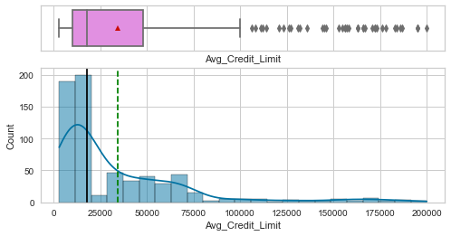

```python
histogram_boxplot(df, "Avg_Credit_Limit", kde=True, figsize=(8, 4))
```

**Observations**

- This distribution is heavily right skewed
- Boxplot shows that the values greater than 100000 are outliers.

```python
df[df["Avg_Credit_Limit"] > 100000]
```

|  | Customer Key | Avg_Credit_Limit | Total_Credit_Cards | Total_visits_bank | Total_visits_online | Total_calls_made |
| --- | --- | --- | --- | --- | --- | --- |
| 612 | 94391 | 157000 | 9 | 1 | 14 | 1 |
| 614 | 40019 | 163000 | 8 | 1 | 7 | 1 |
| 615 | 77910 | 131000 | 9 | 1 | 10 | 1 |
| 617 | 98216 | 136000 | 8 | 0 | 13 | 0 |
| 618 | 54495 | 121000 | 7 | 0 | 13 | 2 |
| 619 | 47650 | 158000 | 7 | 0 | 13 | 0 |
| 620 | 32107 | 108000 | 10 | 0 | 15 | 1 |
| 621 | 84192 | 166000 | 9 | 1 | 12 | 2 |
| 622 | 53916 | 176000 | 10 | 1 | 15 | 2 |
| 623 | 32584 | 166000 | 10 | 0 | 7 | 0 |
| 624 | 97285 | 178000 | 7 | 0 | 11 | 0 |
| 626 | 15585 | 156000 | 9 | 1 | 10 | 2 |
| 627 | 20620 | 146000 | 10 | 0 | 12 | 1 |
| 629 | 76203 | 155000 | 8 | 0 | 7 | 2 |
| 630 | 33837 | 200000 | 10 | 0 | 13 | 0 |
| 631 | 14916 | 195000 | 8 | 0 | 15 | 0 |
| 632 | 97935 | 187000 | 7 | 1 | 7 | 0 |
| 633 | 16180 | 163000 | 7 | 1 | 10 | 1 |
| 634 | 49493 | 106000 | 8 | 0 | 8 | 1 |
| 635 | 70974 | 114000 | 10 | 1 | 7 | 2 |
| 636 | 40217 | 126000 | 10 | 1 | 8 | 0 |
| 637 | 88442 | 173000 | 9 | 1 | 11 | 0 |
| 638 | 17538 | 153000 | 8 | 1 | 7 | 1 |
| 639 | 90839 | 184000 | 7 | 1 | 15 | 2 |
| 640 | 99843 | 123000 | 8 | 1 | 15 | 2 |
| 641 | 27212 | 144000 | 10 | 0 | 10 | 2 |
| 644 | 18519 | 127000 | 10 | 1 | 15 | 1 |
| 645 | 48762 | 171000 | 10 | 0 | 15 | 0 |
| 646 | 58392 | 186000 | 7 | 0 | 8 | 1 |
| 647 | 79953 | 183000 | 9 | 0 | 9 | 2 |
| 648 | 13315 | 111000 | 8 | 1 | 7 | 0 |
| 649 | 30570 | 112000 | 10 | 1 | 8 | 1 |
| 650 | 78996 | 195000 | 10 | 1 | 12 | 2 |
| 651 | 78404 | 132000 | 9 | 1 | 12 | 2 |
| 652 | 28525 | 156000 | 8 | 1 | 8 | 0 |
| 654 | 65750 | 172000 | 10 | 1 | 9 | 1 |
| 657 | 53834 | 145000 | 8 | 1 | 9 | 1 |
| 658 | 80655 | 172000 | 10 | 1 | 15 | 0 |
| 659 | 80150 | 167000 | 9 | 0 | 12 | 2 |

- These outliers seem to be valid credit limits and we will not treat these outliers as they represent the real market trend

```python
# function to create labeled barplots


def labeled_barplot(data, feature, perc=False, n=None):
    """
    Barplot with percentage at the top

    data: dataframe
    feature: dataframe column
    perc: whether to display percentages instead of count (default is False)
    n: displays the top n category levels (default is None, i.e., display all levels)
    """

    total = len(data[feature])  # length of the column
    count = data[feature].nunique()
    if n is None:
        plt.figure(figsize=(count + 1, 5))
    else:
        plt.figure(figsize=(n + 1, 5))

    plt.xticks(rotation=90, fontsize=15)
    ax = sns.countplot(
        data=data,
        x=feature,
        palette="Paired",
        order=data[feature].value_counts().index[:n].sort_values(),
    )

    for p in ax.patches:
        if perc == True:
            label = "{:.1f}%".format(
                100 * p.get_height() / total
            )  # percentage of each class of the category
        else:
            label = p.get_height()  # count of each level of the category

        x = p.get_x() + p.get_width() / 2  # width of the plot
        y = p.get_height()  # height of the plot

        ax.annotate(
            label,
            (x, y),
            ha="center",
            va="center",
            size=12,
            xytext=(0, 5),
            textcoords="offset points",
        )  # annotate the percentage

    plt.show()  # show the plot
```

### Observations on Total Credit Cards

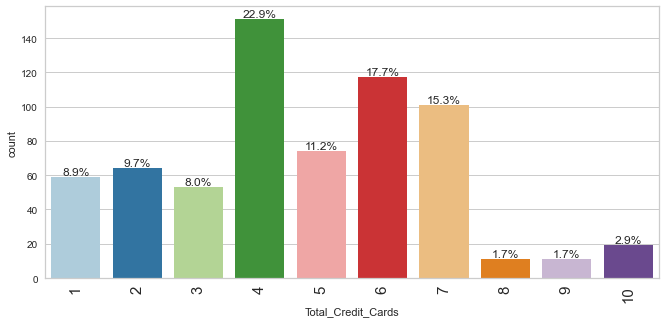

```python
labeled_barplot(df, "Total_Credit_Cards", perc=True)
```

### Observations on Total Visits Bank

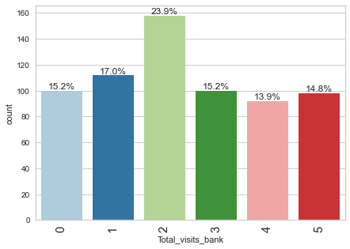

```python
labeled_barplot(df, "Total_visits_bank", perc=True)
```

**Observations**

- Most customers make a total of 2 persoal visits to the bank in a year followed by 1 visit
- Equal percentage of people make 0 and 3 visits to the bank in a year

### Observations on Total Visits Online

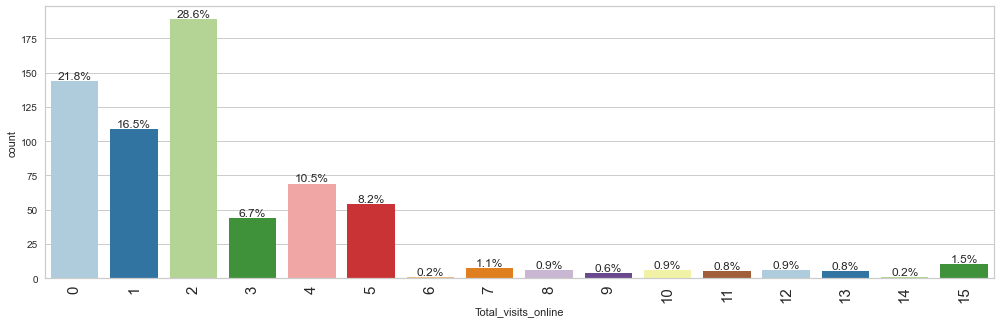

```python
labeled_barplot(df, "Total_visits_online", perc=True)
```

### Observations on Total Calls Made

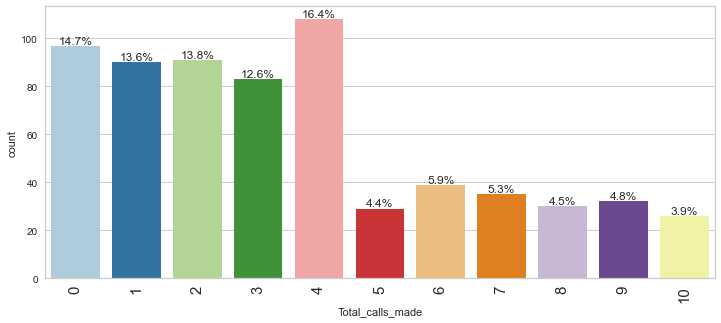

```python
labeled_barplot(df, "Total_calls_made", perc=True)
```

**Observations**

- 16.4% of customers make 4 calls to the bank or its customer service department in a year
- 14.7% of customers NEVER make a call to the bank or its customer service department in a year
- Equal percentage of people make 1 or 2 calls per year to the bank or its customer service department

## Bivariate Analysis

### Correlation between numerical variables

```python
# Look at the correlation of the numerical columns. Ignore the customer key
subset_df = df.drop("Customer Key", axis=1)

numerical_cols = subset_df.columns.tolist()
```

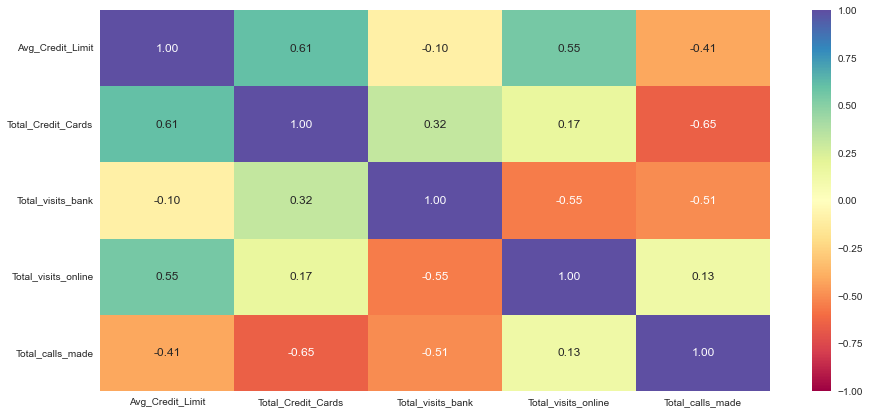

```python
plt.figure(figsize=(15, 7))
sns.heatmap(
    subset_df.corr(), annot=True, vmin=-1, vmax=1, fmt=".2f", cmap="Spectral",
)
plt.show()
```

**Observations**

- There is a positive correlation between Average Credit Limit and Total Credit Cards, Total visits online
- There is a negative correlation between Total calls made and Average Credit Limit, Total Credit Cards, Total Bank Visits
- There is a negative correlation between Total visits online and Total visits bank. This is obvious because if people are visiting the bank in person, they visit the bank website less.

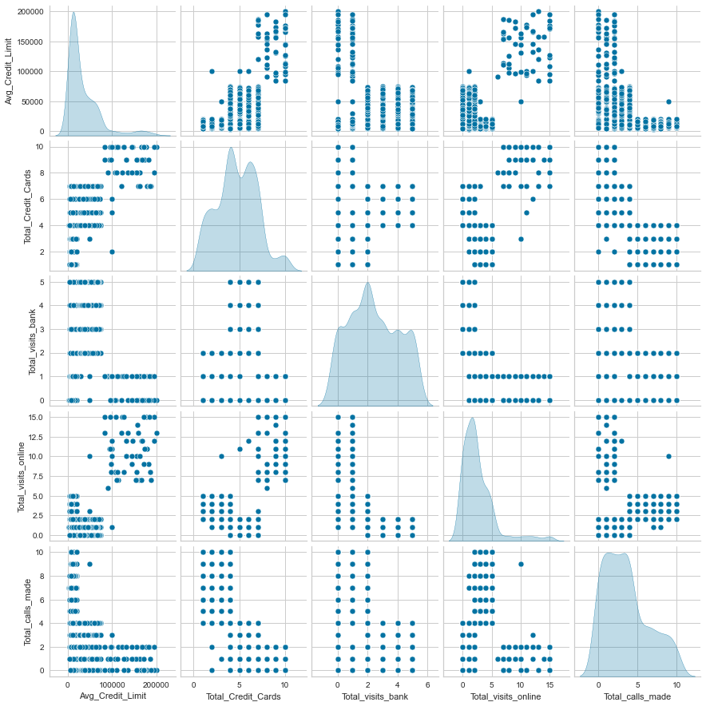

```python
sns.pairplot(data=subset_df, diag_kind="kde")
plt.show()
```

**Observations**

- All the kde graphs (along the diagonals) are multi modal
- We see that `Total_Credit_Cards` and `Total_visits_bank` have 3 peaks in the kde plot. So we require atleast 3 clusters

# Data Pre-Processing Contd.

## Scale the data

```python
# Let's scale the data before we proceed to cluster it.
scaler = StandardScaler()
subset_scaled = scaler.fit_transform(subset_df)

# Creating a dataframe from the scaled data
subset_scaled_df = pd.DataFrame(subset_scaled, columns=subset_df.columns)
subset_scaled_df.head()
```

|  | Avg_Credit_Limit | Total_Credit_Cards | Total_visits_bank | Total_visits_online | Total_calls_made |
| --- | --- | --- | --- | --- | --- |
| 0 | 1.740187 | -1.249225 | -0.860451 | -0.547490 | -1.251537 |
| 1 | 0.410293 | -0.787585 | -1.473731 | 2.520519 | 1.891859 |
| 2 | 0.410293 | 1.058973 | -0.860451 | 0.134290 | 0.145528 |
| 3 | -0.121665 | 0.135694 | -0.860451 | -0.547490 | 0.145528 |
| 4 | 1.740187 | 0.597334 | -1.473731 | 3.202298 | -0.203739 |

```python
kmeans_df = df.copy()
hc_df = df.copy()

kmeans_subset_df = subset_df.copy()
hc_subset_df = subset_df.copy()

kmeans_scaled_df = subset_scaled_df.copy()
hc_scaled_df = subset_scaled_df.copy()
```

# K-means Clustering

```python
# Calculate the average distortion for each k
clusters = range(1, 9)
meanDistortions = []

for k in clusters:
    kmeansModel = KMeans(n_clusters=k, random_state=1)
    kmeansModel.fit(kmeans_scaled_df)
    prediction = kmeansModel.predict(kmeans_scaled_df)
    distortion = (
        sum(
            np.min(
                cdist(kmeans_scaled_df, kmeansModel.cluster_centers_, "euclidean"),
                axis=1,
            )
        )
        / kmeans_scaled_df.shape[0]
    )

    meanDistortions.append(distortion)

    print("Number of Clusters:", k, "\tAverage Distortion:", distortion)
```

```
Number of Clusters: 1 	Average Distortion: 2.0069222262503614
Number of Clusters: 2 	Average Distortion: 1.4571553548514269
Number of Clusters: 3 	Average Distortion: 1.1466276549150365
Number of Clusters: 4 	Average Distortion: 1.0463825294774465
Number of Clusters: 5 	Average Distortion: 0.9908683849620168
Number of Clusters: 6 	Average Distortion: 0.9426543606899347
Number of Clusters: 7 	Average Distortion: 0.9093991915419353
Number of Clusters: 8 	Average Distortion: 0.8843243844476886
```

## Elbow Method

Using the elbow method to find out the optimal number of clusters

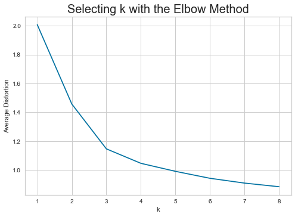

```python
plt.plot(clusters, meanDistortions, "bx-")
plt.xlabel("k")
plt.ylabel("Average Distortion")
plt.title("Selecting k with the Elbow Method", fontsize=20)
```

**The appropriate value of k from the elbow curve seems to be 3 or 4**

## Silhouette Score

Silhouette Score gives a perspective into the density and separation of the formed clusters

```
For n_clusters = 2, silhouette score is 0.41842496663215445
For n_clusters = 3, silhouette score is 0.5157182558881063
For n_clusters = 4, silhouette score is 0.3556670619372605
For n_clusters = 5, silhouette score is 0.2717470361089752
For n_clusters = 6, silhouette score is 0.2558123746389958
For n_clusters = 7, silhouette score is 0.2482162264085859
For n_clusters = 8, silhouette score is 0.2269344482628141
For n_clusters = 9, silhouette score is 0.2197094471729576
```

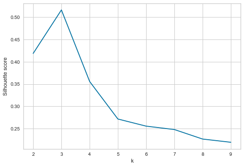

```python
# Let's check the silhouette scores.
sil_score = []
cluster_list = list(range(2, 10))
for n_clusters in cluster_list:
    clusterer = KMeans(n_clusters=n_clusters, random_state=10)
    preds = clusterer.fit_predict((kmeans_scaled_df))
    score = silhouette_score(kmeans_scaled_df, preds)
    sil_score.append(score)
    print("For n_clusters = {}, silhouette score is {}".format(n_clusters, score))

plt.plot(cluster_list, sil_score)
plt.xlabel("k")
plt.ylabel("Silhouette score")
```

**From the silhouette scores, it seems that 3 is a good value of k.**

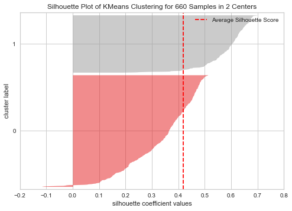

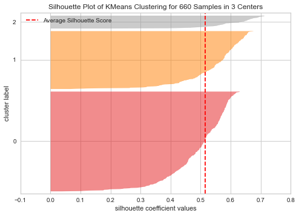

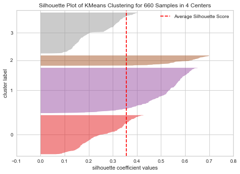

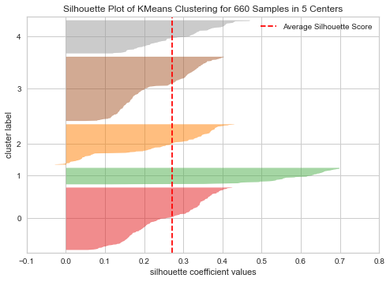

```python
# finding optimal no. of clusters with silhouette coefficients
cluster_list = list(range(2, 6))
for n_clusters in cluster_list:
    kmclusterer = KMeans(n_clusters=n_clusters, random_state=10)
    visualizer = SilhouetteVisualizer(kmclusterer)
    visualizer.fit(kmeans_scaled_df)
    visualizer.show()
```

- The silhouette plot shows that the n_clusters value of 2, 4 and 5 are a bad pick for the given data due to the presence of clusters with below average silhouette scores and also due to wide fluctuations in the size of the silhouette plots.
- The silhouette plot for cluster 0 when n_clusters is equal to 3 is bigger in size

**Let's take 3 as the appropriate no. of clusters as the silhouette score is high enough and there is knick at 3 in the elbow curve.**

## Cluster Profiling

```python
%%timeit -r1 -n1
# K-means cluster model
kmeans = KMeans(n_clusters=3, random_state=0)
kmeans.fit(kmeans_scaled_df)

# adding kmeans cluster labels to the original dataframe
kmeans_df["K_means_segments"] = kmeans.labels_
kmeans_subset_df["K_means_segments"] = kmeans.labels_
```

```
23 ms ± 0 ns per loop (mean ± std. dev. of 1 run, 1 loop each)
```

```python
# used later in silhouette score
labels_kmeans = kmeans_df["K_means_segments"]
```

```python
# calculate the mean for the cluster group
cluster_profile = kmeans_subset_df.groupby("K_means_segments").mean()
```

```python
cluster_profile["count_in_each_segment"] = (
    kmeans_subset_df.groupby("K_means_segments")["Total_calls_made"].count().values
)
```

```python
# let's see the ids of the customers in each cluster
for cl in kmeans_df["K_means_segments"].unique():
    print(
        "The",
        kmeans_df[kmeans_df["K_means_segments"] == cl]["Customer Key"].nunique(),
        "customers in cluster",
        cl,
        "are:",
    )
    #    print("In cluster {}, the following customers are present:".format(cl))
    print(kmeans_df[kmeans_df["K_means_segments"] == cl]["Customer Key"].unique())
    print()
```

```
The 384 customers in cluster 0 are:
[87073 17341 40496 54838 35254 46635 97825 83125 35483 15129 83290 56486
 31903 45909 14263 46813 81878 35549 85799 39122 81531 69965 18595 44398
 32352 40898 27101 33457 45088 23302 27408 65372 21531 56843 17165 89328
 20072 71402 47496 24808 17036 67193 34423 97109 55382 51811 53936 66504
 53207 18514 51319 36340 36934 95925 49771 22919 21233 74544 52025 45652
 73952 49418 77026 49331 75775 54906 94666 11698 34677 95610 41380 38033
 85337 38994 67911 92956 77641 57565 53814 30712 19785 31384 16374 50878
 78002 83459 91987 51552 24998 45673 11596 87485 28414 81863 33240 11466
 23881 44645 49844 92782 22824 26767 26678 50412 17933 34495 47437 22610
 41159 64672 62483 85614 96548 19137 69028 70779 38244 67046 64897 46223
 36628 17565 77381 11799 81940 66706 87838 94437 33790 44402 29886 66804
 47866 61996 15318 89635 71681 71862 96186 22348 36243 88807 82376 98126
 80347 17649 62807 92522 57459 44579 45476 61994 11398 24702 27824 45878
 72431 19215 23409 16418 85122 55060 55478 65574 31113 96929 78912 68439
```

[output cut: 46 more lines]

```python
# let's display cluster profiles
cluster_profile.style.highlight_max(color="lightgreen", axis=0)
```

| K_means_segments | Avg_Credit_Limit | Total_Credit_Cards | Total_visits_bank | Total_visits_online | Total_calls_made | count_in_each_segment |
| --- | --- | --- | --- | --- | --- | --- |
| 0 | 33782.383420 | 5.515544 | 3.489637 | 0.981865 | 2.000000 | 386 |
| 1 | 12174.107143 | 2.410714 | 0.933036 | 3.553571 | 6.870536 | 224 |
| 2 | 141040.000000 | 8.740000 | 0.600000 | 10.900000 | 1.080000 | 50 |

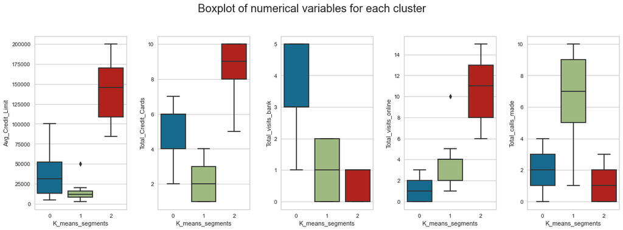

```python
# plot the box plot
fig, axes = plt.subplots(1, 5, figsize=(16, 6))
fig.suptitle("Boxplot of numerical variables for each cluster", fontsize=20)
counter = 0
for ii in range(5):
    sns.boxplot(
        ax=axes[ii],
        y=kmeans_subset_df[numerical_cols[counter]],
        x=kmeans_subset_df["K_means_segments"],
    )
    counter = counter + 1

fig.tight_layout(pad=2.0)
```

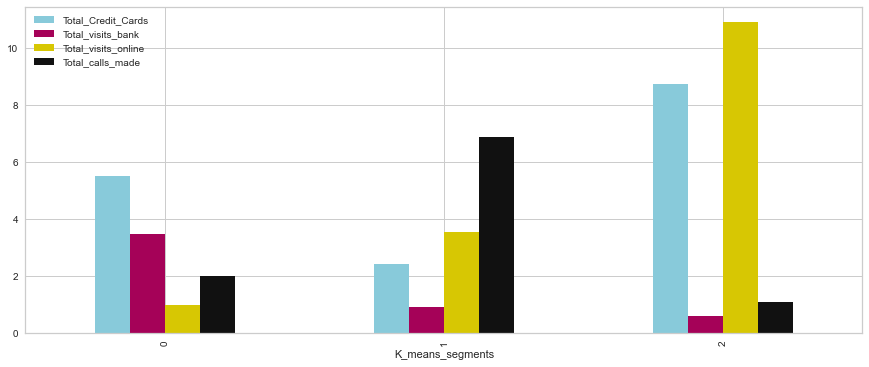

```python
# plot the bar graph for the numerical columns
kmeans_subset_df.drop("Avg_Credit_Limit", axis=1).groupby(
    "K_means_segments"
).mean().plot.bar(figsize=(15, 6), color=list("cmyk"))
```

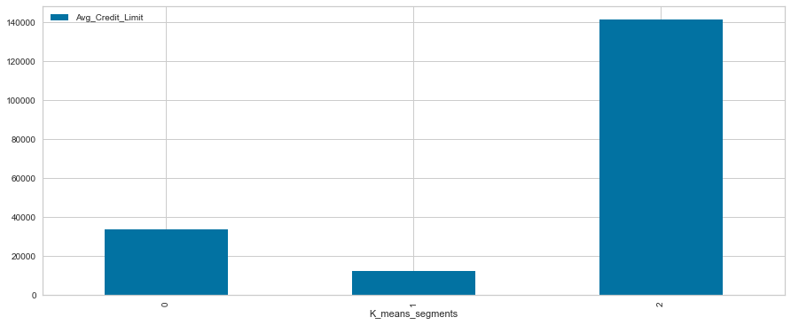

```python
kmeans_subset_df[["Avg_Credit_Limit", "K_means_segments"]].groupby(
    "K_means_segments"
).mean().plot.bar(figsize=(15, 6))
```

# Hierarchical Clustering

## Cophenetic Correlation

```python
# list of distance metrics
distance_metrics = ["euclidean", "chebyshev", "mahalanobis", "cityblock"]

# list of linkage methods
linkage_methods = ["single", "complete", "average", "weighted"]

high_cophenet_corr = 0
high_dm_lm = [0, 0]

for dm in distance_metrics:
    for lm in linkage_methods:
        Z = linkage(hc_scaled_df, metric=dm, method=lm)
        c, coph_dists = cophenet(Z, pdist(hc_scaled_df))
        print(
            "Cophenetic correlation for {} distance and {} linkage is {}.".format(
                dm.capitalize(), lm, c
            )
        )
        if high_cophenet_corr < c:
            high_cophenet_corr = c
            high_dm_lm[0] = dm
            high_dm_lm[1] = lm
```

```
Cophenetic correlation for Euclidean distance and single linkage is 0.7391220243806552.
Cophenetic correlation for Euclidean distance and complete linkage is 0.8599730607972423.
Cophenetic correlation for Euclidean distance and average linkage is 0.8977080867389372.
Cophenetic correlation for Euclidean distance and weighted linkage is 0.8861746814895477.
Cophenetic correlation for Chebyshev distance and single linkage is 0.7382354769296767.
Cophenetic correlation for Chebyshev distance and complete linkage is 0.8533474836336782.
Cophenetic correlation for Chebyshev distance and average linkage is 0.8974159511838106.
Cophenetic correlation for Chebyshev distance and weighted linkage is 0.8913624010768603.
Cophenetic correlation for Mahalanobis distance and single linkage is 0.7058064784553606.
Cophenetic correlation for Mahalanobis distance and complete linkage is 0.5422791209801747.
Cophenetic correlation for Mahalanobis distance and average linkage is 0.8326994115042134.
Cophenetic correlation for Mahalanobis distance and weighted linkage is 0.7805990615142516.
Cophenetic correlation for Cityblock distance and single linkage is 0.7252379350252723.
Cophenetic correlation for Cityblock distance and complete linkage is 0.8731477899179829.
Cophenetic correlation for Cityblock distance and average linkage is 0.896329431104133.
Cophenetic correlation for Cityblock distance and weighted linkage is 0.8825520731498188.
```

```python
# printing the combination of distance metric and linkage method with the highest cophenetic correlation
print(
    "Highest cophenetic correlation is {}, which is obtained with {} distance and {} linkage.".format(
        high_cophenet_corr, high_dm_lm[0].capitalize(), high_dm_lm[1]
    )
)
```

```
Highest cophenetic correlation is 0.8977080867389372, which is obtained with Euclidean distance and average linkage.
```

**Let us explore different linkage methods with Euclidean distance only**

```python
# list of linkage methods
linkage_methods = ["single", "complete", "average", "centroid", "ward", "weighted"]

high_cophenet_corr = 0
high_dm_lm = [0, 0]

for lm in linkage_methods:
    Z = linkage(hc_scaled_df, metric="euclidean", method=lm)
    c, coph_dists = cophenet(Z, pdist(hc_scaled_df))
    print("Cophenetic correlation for {} linkage is {}.".format(lm, c))
    if high_cophenet_corr < c:
        high_cophenet_corr = c
        high_dm_lm[0] = "euclidean"
        high_dm_lm[1] = lm
```

```
Cophenetic correlation for single linkage is 0.7391220243806552.
Cophenetic correlation for complete linkage is 0.8599730607972423.
Cophenetic correlation for average linkage is 0.8977080867389372.
Cophenetic correlation for centroid linkage is 0.8939385846326323.
Cophenetic correlation for ward linkage is 0.7415156284827493.
Cophenetic correlation for weighted linkage is 0.8861746814895477.
```

```python
# printing the combination of distance metric and linkage method with the highest cophenetic correlation
print(
    "Highest cophenetic correlation is {}, which is obtained with {} linkage.".format(
        high_cophenet_corr, high_dm_lm[1]
    )
)
```

```
Highest cophenetic correlation is 0.8977080867389372, which is obtained with average linkage.
```

**We see that the cophenetic correlation is maximum with Euclidean distance and average linkage.**

## Dendrograms

**Let's see the dendrograms for the different linkage methods.**

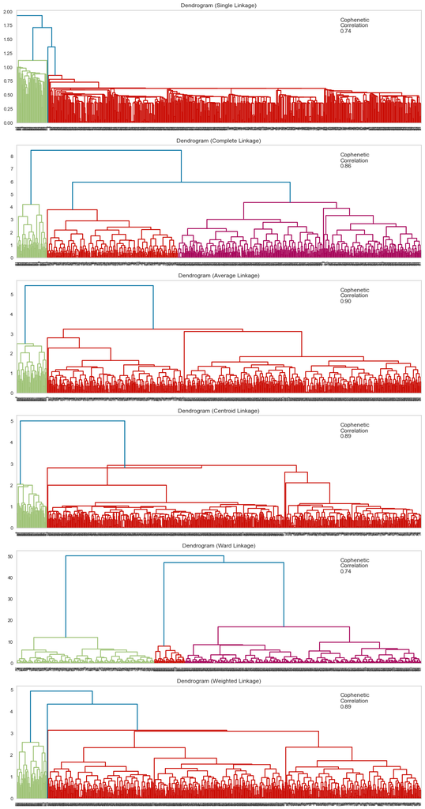

```python
# list of linkage methods
linkage_methods = ["single", "complete", "average", "centroid", "ward", "weighted"]

# lists to save results of cophenetic correlation calculation
compare_cols = ["Linkage", "Cophenetic Coefficient"]

# to create a subplot image
fig, axs = plt.subplots(len(linkage_methods), 1, figsize=(15, 30))

# We will enumerate through the list of linkage methods above
# For each linkage method, we will plot the dendrogram and calculate the cophenetic correlation
for i, method in enumerate(linkage_methods):
    Z = linkage(hc_scaled_df, metric="euclidean", method=method)

    dendrogram(Z, ax=axs[i])
    axs[i].set_title(f"Dendrogram ({method.capitalize()} Linkage)")
    axs[i].grid(False)

    coph_corr, coph_dist = cophenet(Z, pdist(hc_scaled_df))
    axs[i].annotate(
        f"Cophenetic\nCorrelation\n{coph_corr:0.2f}",
        (0.80, 0.80),
        xycoords="axes fraction",
    )
```

**The dendrograms look messy. We're mostly interested in the last few clusters anyway. Let's truncate the diagram to make it more interpretable and see how it looks.**

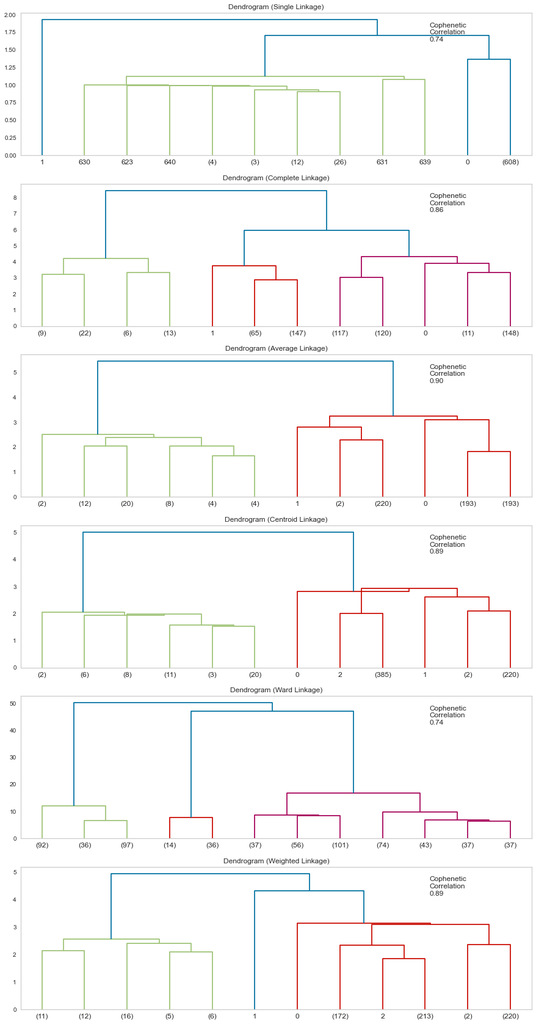

```python
# list of linkage methods
linkage_methods = ["single", "complete", "average", "centroid", "ward", "weighted"]

# lists to save results of cophenetic correlation calculation
compare_cols = ["Linkage", "Cophenetic Coefficient"]

# to create a subplot image
fig, axs = plt.subplots(len(linkage_methods), 1, figsize=(15, 30))

# We will enumerate through the list of linkage methods above
# For each linkage method, we will plot the dendrogram and calculate the cophenetic correlation
for i, method in enumerate(linkage_methods):
    Z = linkage(hc_scaled_df, metric="euclidean", method=method)

    dendrogram(Z, ax=axs[i], truncate_mode="lastp", p=12)
    axs[i].set_title(f"Dendrogram ({method.capitalize()} Linkage)")
    axs[i].grid(False)

    coph_corr, coph_dist = cophenet(Z, pdist(hc_scaled_df))
    axs[i].annotate(
        f"Cophenetic\nCorrelation\n{coph_corr:0.2f}",
        (0.80, 0.80),
        xycoords="axes fraction",
    )
```

**Observations**

- The cophenetic correlation is highest for average and centroid linkage methods.
- We will move ahead with average linkage.
- 3 appears to be the appropriate number of clusters from the dendrogram for average linkage.

## Cluster Profiling

```python
%%timeit -r1 -n1
# Create hierarchical clustering with average linkage and euclidean distance
hc_agg_avg = AgglomerativeClustering(
    n_clusters=3, affinity="euclidean", linkage="average"
)
hc_agg_avg.fit(hc_scaled_df)

hc_subset_df["HC_Clusters"] = hc_agg_avg.labels_
hc_df["HC_Clusters"] = hc_agg_avg.labels_
```

```
9.18 ms ± 0 ns per loop (mean ± std. dev. of 1 run, 1 loop each)
```

```python
labels_hc_avg = hc_df["HC_Clusters"]
```

```python
cluster_profile = hc_subset_df.groupby("HC_Clusters").mean()
```

```python
cluster_profile["count_in_each_segments"] = (
    hc_subset_df.groupby("HC_Clusters")["Avg_Credit_Limit"].count().values
)
```

```python
# let's see the ids of the customers in each cluster
for cl in hc_df["HC_Clusters"].unique():
    print(
        "The",
        hc_df[hc_df["HC_Clusters"] == cl]["Customer Key"].nunique(),
        "customers in cluster",
        cl,
        "are:",
    )
    #    print("In cluster {}, the following customers are present:".format(cl))
    print(hc_df[hc_df["HC_Clusters"] == cl]["Customer Key"].unique())
    print()
```

```
The 385 customers in cluster 0 are:
[87073 17341 40496 54838 35254 46635 97825 83125 35483 15129 83290 56486
 31903 45909 14263 46813 81878 35549 85799 39122 81531 69965 18595 44398
 32352 40898 27101 33457 45088 23302 27408 65372 21531 56843 17165 89328
 20072 71402 47496 24808 17036 67193 34423 97109 55382 51811 53936 66504
 53207 18514 51319 36340 36934 95925 49771 22919 21233 74544 52025 45652
 73952 49418 77026 49331 75775 54906 94666 11698 34677 95610 41380 38033
 85337 38994 67911 92956 77641 57565 53814 30712 19785 31384 16374 50878
 78002 83459 91987 51552 72156 24998 45673 11596 87485 28414 81863 33240
 11466 23881 44645 49844 92782 22824 26767 26678 50412 17933 34495 47437
 22610 41159 64672 62483 85614 96548 19137 69028 70779 38244 67046 64897
 46223 36628 17565 77381 11799 81940 66706 87838 94437 33790 44402 29886
 66804 47866 61996 15318 89635 71681 71862 96186 22348 36243 88807 82376
 98126 80347 17649 62807 92522 57459 44579 45476 61994 11398 24702 27824
 45878 72431 19215 23409 16418 85122 55060 55478 65574 31113 96929 78912
```

[output cut: 47 more lines]

```python
# lets display cluster profile
cluster_profile.style.highlight_max(color="lightgreen", axis=0)
```

| HC_Clusters | Avg_Credit_Limit | Total_Credit_Cards | Total_visits_bank | Total_visits_online | Total_calls_made | count_in_each_segments |
| --- | --- | --- | --- | --- | --- | --- |
| 0 | 33713.178295 | 5.511628 | 3.485788 | 0.984496 | 2.005168 | 387 |
| 1 | 141040.000000 | 8.740000 | 0.600000 | 10.900000 | 1.080000 | 50 |
| 2 | 12197.309417 | 2.403587 | 0.928251 | 3.560538 | 6.883408 | 223 |

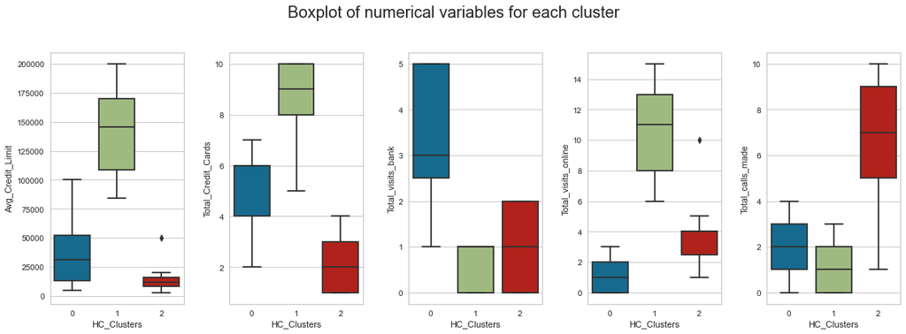

```python
# plot the box plot
fig, axes = plt.subplots(1, 5, figsize=(16, 6))
fig.suptitle("Boxplot of numerical variables for each cluster", fontsize=20)
counter = 0
for ii in range(5):
    sns.boxplot(
        ax=axes[ii], y=hc_df[numerical_cols[counter]], x=hc_df["HC_Clusters"],
    )
    counter = counter + 1

fig.tight_layout(pad=2.0)
```

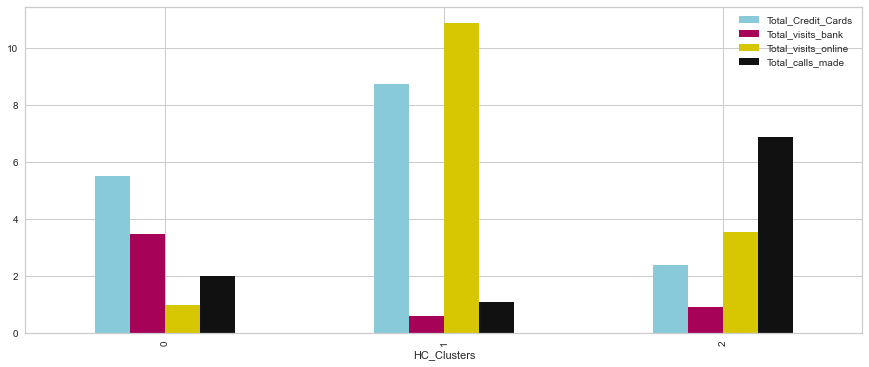

```python
# plot the bar plot
hc_subset_df.drop("Avg_Credit_Limit", axis=1).groupby("HC_Clusters").mean().plot.bar(
    figsize=(15, 6), color=list("cmyk")
)
```

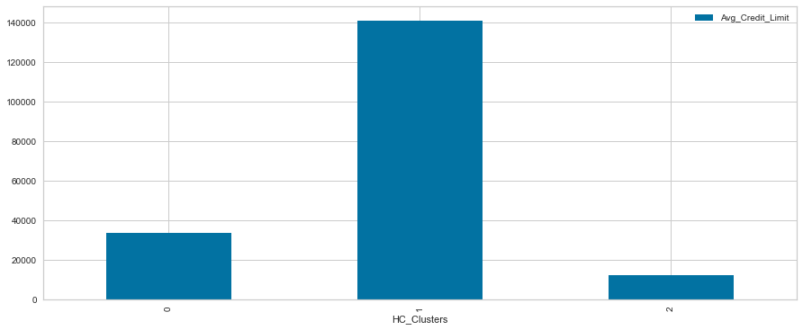

```python
hc_subset_df[["Avg_Credit_Limit", "HC_Clusters"]].groupby(
    "HC_Clusters"
).mean().plot.bar(figsize=(15, 6))
```

# Compare K-means and Hierachical Clustering

## Clustering performance evaluation - Silhouette coefficient

- Silhouette score is calculated using the mean intra-cluster distance, as well as the mean distance to the nearest cluster for each sample in the dataset.
- This metric is bounded between -1 and 1. Closer to -1 suggests incorrect clustering, while closer to +1 shows that each cluster is very dense.

```python
print(
    f"Silhouette score for K-means clustering is {silhouette_score(subset_scaled_df, labels_kmeans)}"
)
```

```
Silhouette score for K-means clustering is 0.5157182558881063
```

```python
print(
    f"Silhouette score for Hierarchical clustering is {silhouette_score(hc_scaled_df, labels_hc_avg)}"
)
```

```
Silhouette score for Hierarchical clustering is 0.515922432650965
```

## Clustering performance evaluation - Calinski-Harabaz Index

- The Calinski-Harabaz Index is a variance ratio measurement which measures the ratio between within-cluster dispersion and between-cluster dispersion.
- This score is not bounded. The higher, the better.

```python
print(
    f"Variance ratio for K-means clustering is {calinski_harabasz_score(subset_scaled_df, labels_kmeans)}"
)
```

```
Variance ratio for K-means clustering is 833.3426265239772
```

```python
print(
    f"Variance ratio for Hierarchical clustering is {calinski_harabasz_score(subset_scaled_df, labels_hc_avg)}"
)
```

```
Variance ratio for Hierarchical clustering is 833.1528581711207
```

## Comparison

**Similarities**

- Both the clustering techniques produced similar clusters
- Both clustering techniques resulted in 3 clusters
- The count of observations in each of the 3 k-means clusters had almost equal no of items when compared to 3 clusters from hierarchical clustering. The observations in the 3 clusters were also very similar between the two techniques.
- Silhouette score and Variance ratio measurement are almost the same for both the clustering techniques
- The cluster profile mean values were similar between both clustering techniques. This is expected since the cluster size, the count of distributions in the cluster are similar in the output of both the techniques

**Differences**

**We will choose the hierarchical clustering model since it is executing faster compared to the k-means model**

# Customer Insights

There are 3 customer segments identified by the model

**Cluster 0**

- Average credit limits are moderate to high
- Have moderate number (average of 5) of credit cards
- Very high number of personal visits to the bank
- Very low online logins and visits to bank website
- Moderate number of calls made to the call center

**Cluster 1**

- Average credit limits are very high
- Have very high number (avg of 9) of credit cards
- Low number of personal visits to the bank
- Very high online logins and visits to bank website
- Low number of calls made to the call center

**Cluster 2**

- Average credit limit is low
- Have low number (avg of 2) of credit cards
- Moderate number of personal visits to the bank
- Moderate online logins and visits to bank website
- High number of calls made to the call center

# Business Recommendations

- **Cluster 0**: These are customers with moderate number of credit cards and moderate to high credit limits. These customers make very high number of personal visits to the bank and low online logins. **The bank should target these customers with promotion to use the bank website for informtation and resolving queries. This will resolve the queries faster and would be cost effective for the bank. The bank should also target these customers with offers and coupons so that the customer credit card usage is more**.
- **Cluster 1**: These are customers with very high number of credit cards and very high credit limits. They also do a lot of online logins and visits to the bank website. **These are high networth individuals with high credit limits and do more online banking. The bank should target this group of customers with offers and brand tie-ins so that they spend more on the credit cards and increase the credit card usage**.
- **Cluster 2**: These are customers with low credit limits and low number of credit cards. These customers also make moderate number of personal visits and moderate online logins in the bank website. They also make a high number of calls to the call center. **Bank should target this group of customers to improve the credit card penetration and also increase the credit limits where approprite thereby encouraging more spending on the credit cards. Also, to reduce the number of queries coming to the call center, the bank should consider sending news letters and articles on how to perform most of the common tasks using the website**.